# Part II - Factors influencing the borrower rate for a Prosper loan

## by Doron Dusheiko

## Investigation Overview

The goal of this analysis is to answer the following question: What affects the borrowers interest rate? The analysis focused on the credit grade/prosper rating, occupation, employment state, income range, number of credit lines over the last 7 years, number of inquiries over last 6 months, delinqiencies over last 7 years, public records over last 12 months, debt to income ratio, total number of propser loans, monthly loan payment, listing category and the original loan amount requested.

## Dataset Overview

A dataset consists of 113,937 Prosper loans, including 81 variables such as loan amount, borrower rate/interest rate, loan status, borrower income and many others. 21,314 loans were removed due to creating extreme right-tailed distrubutions in certain variables, making it difficult to gain insight into the data.

## Borrower Rate Distribution

The distribution is slightly right-skewed, with the majority of interest rates being 0.1 and 0.2% with a large spike at 0.3177.

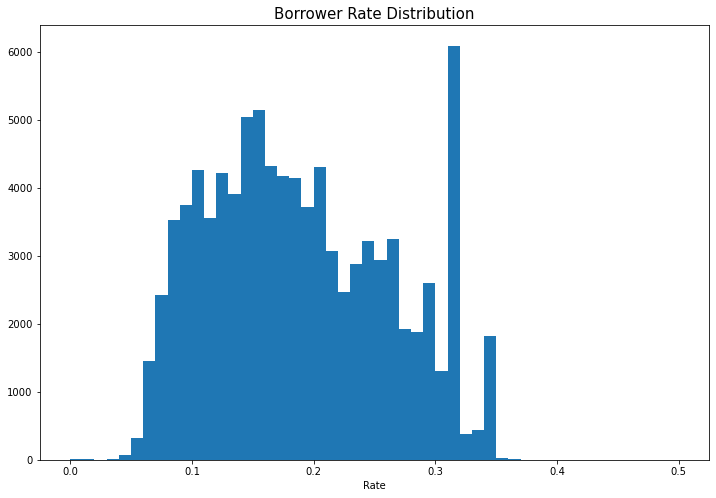

## Borrower Rate as a function of Prosper Rating (post-July 2009) and Credit Grade (pre-July 2009)

As CreditGrade and ProsperRating improve, the mean borrower rate comes down, showing this is a key variable

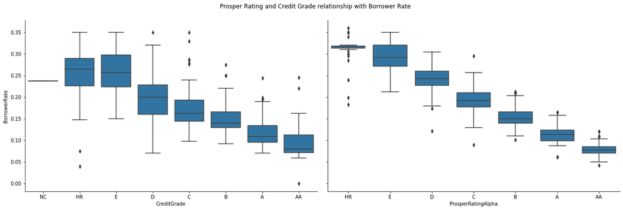

## Relationship between Borrower Rate, Employment Status and Income Range

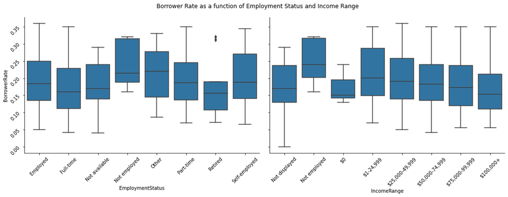

## Relationship between Income Range, Employment Status and Prosper Rating

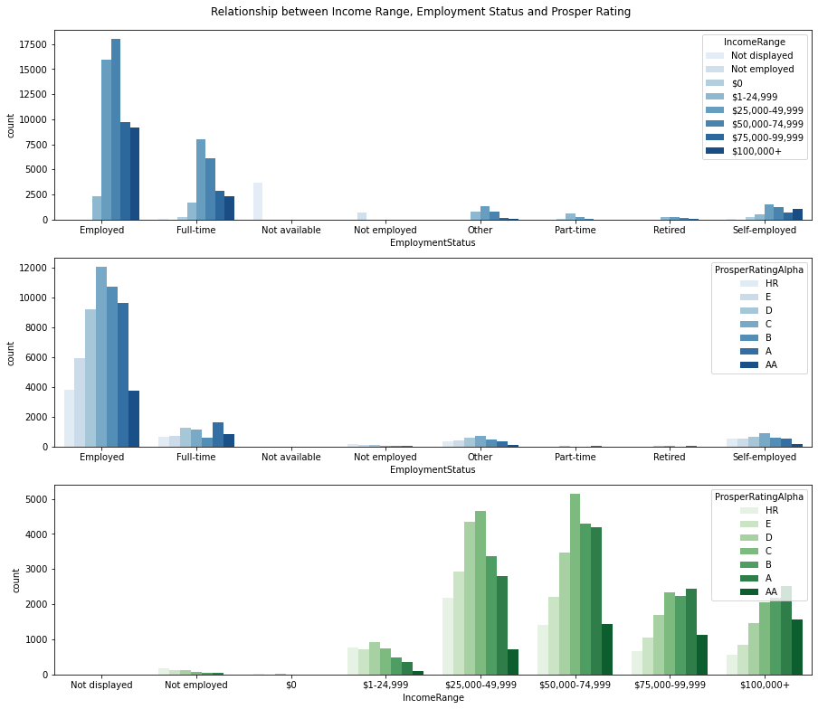

## Borrower Rate and Debt to Income Ratio by Home Ownership

From the distribution of Borrower Rate as a function of home ownership, we can see that being a home owner does attract a slightly better borrower rate.

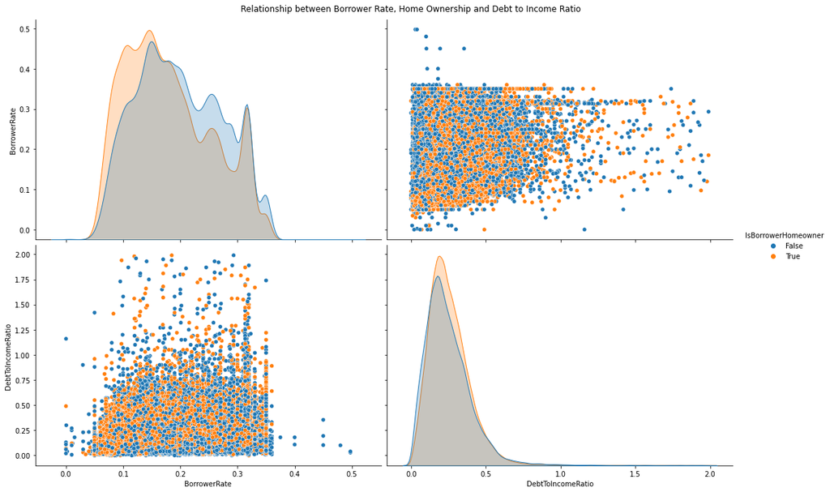